# IBD Clinical Trial Analysis (Rabinowitz-Silver)

Kevin Willliams

September 14, 2021

## Introduction

This is a synopsis of the steps undertaken to remediate the SAS code used in the initial analysis supporting the manuscript, *“Assessment of the inclusion of female racial/ethnic minority, female, and older individuals in inflammatory bowel disease clinical trials”* **(Rabinowitz, Silver et al.)**, into the R programming language. Where appropriate, samples of the exact R syntax used will be displayed, along with the corresponding output (tabular data, graphical plots, maps, etc.).

### Analytic Tasks

- Import .xlsx file into R
- Scrub data, ensuring that variables such as “Interventions,” “Funded by” and “Category” are consistently represented
- Run series of requested descriptive statistics on various variables of interest
- Produce a chloropleth map showing the countries assisting in the referenced US-based IBD clinical trials
- Tests various hypotheses around the racial, age and gender distributions of the participants enrolled in these trials

#### Task 1: Import data from Excel, save it as `IBD` and remove problematic characaters from all variable names.

```r
require(xlsx)
require(tidyverse)
require(dplyr)
require(broom)

IBD <- read_excel("~/Documents/R/IBD Clinical Trials Paper/IBD Disparities 5-30.xlsx")


# make.names function essentially replaces all spaces and non-standard characters (parens, brackets, etc.) with a series of periods

names(IBD)<-  make.names(names(IBD),unique = TRUE)
```

Here’s a glimpse of the structure of the resulting dataset – where only the column names were modified – which was named `IBD`:

```r
glimpse(IBD)
```

```
## Rows: 146
## Columns: 56
## $ Title                                                                                                                                                 <chr> …
## $ Conditions                                                                                                                                            <chr> …
## $ Category..CD..UC..IBD.                                                                                                                                <chr> …
## $ Interventions                                                                                                                                         <chr> …
## $ Intervention.Group                                                                                                                                    <chr> …
## $ Sex.Included                                                                                                                                          <chr> …
## $ Were.pregnant.breastfeeding.women.excluded.from.trial.                                                                                                <chr> …
## $ Phases                                                                                                                                                <chr> …
## $ Phases.Paired                                                                                                                                         <dbl> …
## $ Funded.By                                                                                                                                             <chr> …
## $ Study.Designs                                                                                                                                         <chr> …
## $ Randomized..Y.N.                                                                                                                                      <chr> …
## $ Start.Date                                                                                                                                            <dttm> …
```

[output cut: 43 more lines]

#### Task 2: Reduce dataset to include only essential variables and use those variables to create *additional* variables for later analyses

```r
# Create smaller data table that has only the variables of interest

IBD2 <-

    IBD %>%


  select( "Title", "Category..CD..UC..IBD.", "Interventions",
          "Funded.By", "Age.Continuous..Mean.",
          "Analyzed", "Female.N", "Included.International.Sites..Y.N.",
          "Race.Reported..Y.N...Race..American.Indian.or.Alaska.Native..Asian..Black.or.African.American..Native.Hawaiian.or.Other.Pacific.Islander..and.White..",
          'Were.pregnant.breastfeeding.women.excluded.from.trial.',
          "Ethnicity.Reported..Y.N...Ethnicity..Hispanic.or.Latino..and..Not.Hispanic.or.Latino....",
          "White.N", "Black.or.African.American.N", "Asian.N",
          "American.Indian.Alaska.Native.N", "Native.Hawaiian.Pacific.Islander.N",
          "More.than.One.Race.Reported.N", "Unknown.Not.Reported.N","Hispanic.N",
          "Age..0.18.child..18...Adult.",
          "Included...65.years..Y.N.",
          "Included....85..Y.N.",
          "X.65.N",
          "LOCATIONS2") %>%

      rename( CATEGORY = "Category..CD..UC..IBD.",
              Funding = "Funded.By", Intervention= "Interventions",
              CONT_MEAN = "Age.Continuous..Mean.",
              FEMALES = "Female.N" ,
              AGE_RANGE = "Age..0.18.child..18...Adult.",
              PLUS65= "Included...65.years..Y.N.",
              PLUS85= "Included....85..Y.N.",
              INTL_SITES = "Included.International.Sites..Y.N.",
              PREGNANT_EXCL = 'Were.pregnant.breastfeeding.women.excluded.from.trial.',
              RACE_REPORTED = "Race.Reported..Y.N...Race..American.Indian.or.Alaska.Native..Asian..Black.or.African.American..Native.Hawaiian.or.Other.Pacific.Islander..and.White..",
              ETHNICITY_REPORTED = "Ethnicity.Reported..Y.N...Ethnicity..Hispanic.or.Latino..and..Not.Hispanic.or.Latino....",
              WHT = "White.N",
              BLK = "Black.or.African.American.N",
              ASN = "Asian.N", AIA = "American.Indian.Alaska.Native.N",
              HPI = "Native.Hawaiian.Pacific.Islander.N",
              MIX= "More.than.One.Race.Reported.N",
              UNK = "Unknown.Not.Reported.N",
              HIS= "Hispanic.N",
              LOCATIONS  = "LOCATIONS2")  %>%

      rename_all (toupper) %>%

      mutate(CATEGORY = str_replace(str_replace_all(CATEGORY, "IBDU", "IBD"), "IBD", "IBDU"))   %>%
      mutate(RACE_REPORTED = ifelse( (RACE_REPORTED == "not reported" | RACE_REPORTED == "N"), "N", "Y"))  %>%

      rowwise() %>%

      mutate(CATEGORY = paste(sort(unlist(strsplit( CATEGORY, ", ", fixed = TRUE))), collapse = ", ") ) %>%
      mutate( INTERVENTION =   str_replace(str_trim(str_sub( INTERVENTION, 1, str_locate( INTERVENTION, ":")[1] ),"both"),":","") ) %>%

      mutate( FUNDING =  case_when (  str_trim(word(FUNDING, 1, sep=("-")), "both") == "Industry"  ~ "INDUSTRY",
                                        str_trim(word(FUNDING, 1, sep=("-")), "both") == "Other" ~

                                        case_when( str_locate(FUNDING, "Industry")[1] >0 ~ "INDUSTRY",
                                                   str_locate(FUNDING, "Hospital")[1] >0 | str_locate(FUNDING, "Clinic")[1] >0  |
                                                   str_locate(FUNDING, "Health Care")[1] >0 | str_locate(FUNDING, "Medical Center")[1] >0 | str_locate(FUNDING, "Health")[1] >0 |
                                                   str_locate(FUNDING, "NIH")[1] >0 ~ "NIH/HOSPITAL",
                                                   str_locate(FUNDING, "College")[1] >0 |  str_locate(FUNDING, "University")[1] >0 | str_locate(FUNDING, "NIH")[1] >0 ~ "NIH/UNIVERSITY",
                                                   str_locate(FUNDING, "NIH")[1] >0 ~ "NIH/HOSPITAL",
                                                   TRUE ~ "ZZZ"), TRUE ~ "NIH/HOSPITAL")) %>%

      mutate (AGECAT =   case_when (str_locate( AGE_RANGE, ",")[1] >0 ~ 3,
                                    str_locate( AGE_RANGE, "Adult")[1] >0 ~ 2,
                                    str_locate( AGE_RANGE, "Child")[1] >0 ~ 1,
                                    TRUE ~ 99 )) %>%

      mutate (AGECAT = recode_factor ( AGECAT,
                                       "1" = "Children Only",
                                       "2" = "Adults Only",
                                       "3" = "Children & Adults"))  %>%

       mutate (CATEGORY = recode_factor ( CATEGORY,
                                   "CD" = "1. CD",
                                   "UC" = "2. UC",
                                   "IBDU" = "3. IBDU",
                                   .default = "4. COMBO"))  %>%


      mutate( PLUS65 = ifelse( PLUS65=="N/A", "N", PLUS65)) %>%
      mutate( PLUS85 = ifelse( PLUS85=="N/A", "N", PLUS85)) %>%
      mutate(AGE_GE65_N = ifelse( X.65.N >= 0, X.65.N, 0)) %>%
      select ( -X.65.N)

  # reorder the factor levels of categorical variable "CATEGORY"

  IBD2$CATEGORY <- factor( IBD2$CATEGORY, levels= c("1. CD", '2. UC', '3. IBDU', '4. COMBO'))
```

Here’s a glimpse of the modified dataset, which was named `IBD2`:

```r
glimpse (IBD2)
```

```
## Rows: 146
## Columns: 25
## Rowwise:
## $ TITLE              <chr> "Clinical Study Comparing PillCam® Crohn's Capsule …
## $ CATEGORY           <fct> 1. CD, 4. COMBO, 4. COMBO, 1. CD, 2. UC, 1. CD, 2. …
## $ INTERVENTION       <chr> "Device", "Drug", "Drug", "Drug", "Drug", "Drug", "…
## $ FUNDING            <chr> "INDUSTRY", "INDUSTRY", "NIH/HOSPITAL", "INDUSTRY",…
## $ CONT_MEAN          <dbl> NA, 10.56, 43.00, 42.50, 42.80, 35.30, 40.00, 39.50…
## $ ANALYZED           <dbl> 99, 89, 50, 54, 36, 147, 50, 8, 124, 250, 66, 34, 5…
## $ FEMALES            <dbl> 63, 39, 29, 24, 14, 64, 22, 1, 52, 145, 25, 13, 31,…
## $ INTL_SITES         <chr> "Y", "Y", "N", "Y", "Y", "Y", "Y", "N", "Y", "Y", "…
## $ RACE_REPORTED      <chr> "N", "Y", "Y", "Y", "Y", "Y", "Y", "N", "Y", "Y", "…
## $ PREGNANT_EXCL      <chr> "Y", "N", "Y", "Y", "Y", "N", "N", "Y", "Y", "Y", "…
## $ ETHNICITY_REPORTED <chr> "N", "Y", "N", "N", "N", "Y", "N", "N", "Y", "Y", "…
## $ WHT                <dbl> NA, 71, 47, 51, 36, 143, 48, NA, 119, 221, 65, 27, …
## $ BLK                <dbl> NA, 8, 2, 2, NA, 2, NA, NA, 3, 9, 1, 1, 7, 11, 3, 2…
## $ ASN                <dbl> NA, 2, 1, 0, NA, 1, 2, NA, 1, 2, 0, 1, 2, 46, 71, 1…
## $ AIA                <dbl> NA, 0, 0, 1, NA, 0, NA, NA, 0, 1, 0, 0, 2, 2, 3, NA…
## $ HPI                <dbl> NA, 0, 0, 0, NA, 0, NA, NA, 1, 1, 0, 0, NA, 3, NA, …
## $ MIX                <dbl> NA, 3, 0, 0, NA, 0, NA, NA, 0, NA, 0, 0, NA, 1, NA,…
## $ UNK                <dbl> NA, 5, 0, 0, NA, 1, NA, NA, 0, 1, 0, 5, NA, 0, NA, …
## $ HIS                <dbl> NA, 9, NA, NA, NA, 1, NA, NA, 7, 35, 0, 0, NA, 3, 1…
## $ AGE_RANGE          <chr> "Adult", "Child", "Adult", "Adult", "Adult", "Adult…
## $ PLUS65             <chr> "Y", "N", "Y", "N", "N", "N", "N", "Y", "N", "Y", "…
## $ PLUS85             <chr> "N", "N", "Y", "N", "N", "N", "N", "N", "N", "N", "…
## $ LOCATIONS          <chr> "USA, AUSTRIA, ISRAEL", "USA, BELGIUM, CANADA, FRAN…
## $ AGECAT             <fct> Adults Only, Children Only, Adults Only, Adults Onl…
## $ AGE_GE65_N         <dbl> 3, NA, NA, NA, NA, NA, NA, NA, NA, NA, 6, NA, NA, N…
```

#### Task 3: The variable *LOCATIONS* contains character strings of country names that are delimited by commas. This variable needs to be saved as its own file `SITES`, pivoted using a “for loop” so that each country’s participation details can be reported.

```r
# Create new data frame with just the LOCATIONS variable
LOCATIONS <-   IBD2 %>% select(LOCATIONS) %>% tbl_df


# Create a second data frame that will be used the store the pivoted data
SITES <- data.frame( ID= character(0), COUNTRY=character(0), STUDIES= numeric(0)  )


# for loop in action that takes every value in COUNTRY delimited by a comma and sets that value in its own row:

for (j in 1: nrow(LOCATIONS) ){

    y <- 0
    loccount<- str_count( LOCATIONS$LOCATIONS[j], ",")+1

    temp  <- data.frame(  ID= character(0), COUNTRY=character(0), STUDIES= numeric(0) )

    # print( paste("j", j, sep="="))
    # print( paste("countries", loccount, sep="="))


  for (i in 1:loccount ){

  a <- str_trim(word( LOCATIONS$LOCATIONS[j], i, sep=(",")))
  y <- 1

  temp[i, 1:2] = c( paste("TRIAL", j, sep=" "), a )
  temp[i, 3]   = y

  }

  SITES = rbind(SITES, temp)

  if (j==nrow(LOCATIONS)){ rm( a, i, j, loccount, y, temp ) }

}
```

One additional set of “piped” `%>%` commands is needed to collapse the newly created `SITES` data frame compute new variablews: *COUNT, PERCENT* and *QUARTILE* variables:

```r
require(kableExtra)

trialcount<-   sqldf(" select count(distinct(ID)) from SITES ")  %>% pull()

  SITES2 <-
    SITES %>% group_by( COUNTRY ) %>%
    summarise( COUNT = n()) %>%
    arrange( desc(COUNT) ) %>%
    mutate( PERCENT = percent(COUNT /  trialcount ) ) %>%
    mutate( PERCENTILE = round( rank( COUNT )/length( COUNT )*100,2) ) %>%
    mutate (QUARTILE = ntile( (COUNT ), 4)) %>%
    arrange ( desc(QUARTILE, COUNT) ) %>% tbl_df

  kbl(SITES2, booktabs = T, format= "html",
      caption = "<center><strong>Countries Recruiting Subjects for US-based IBD Clinical Trials</strong></center>",
      align= c('l','r','r','r','r'), escape=F,
      col.names = linebreak(c("Country", "Trials<br>N", "Percent", "Percentile", "Quartile"))) %>%

      kable_styling(full_width = F, "hover") %>% column_spec(1, width = "8cm") %>%
      scroll_box(height = "6in")
```

**Countries Recruiting Subjects for US-based IBD Clinical Trials**

| Country | Trials N | Percent | Percentile | Quartile |
| --- | --- | --- | --- | --- |
| USA | 146 | 100.00% | 100.00 | 4 |
| CANADA | 82 | 56.16% | 98.21 | 4 |
| POLAND | 58 | 39.73% | 96.43 | 4 |
| HUNGARY | 53 | 36.30% | 94.64 | 4 |
| BELGIUM | 52 | 35.62% | 92.86 | 4 |
| GERMANY | 51 | 34.93% | 91.07 | 4 |
| CZECHIA | 46 | 31.51% | 89.29 | 4 |
| FRANCE | 44 | 30.14% | 87.50 | 4 |
| NETHERLANDS | 42 | 28.77% | 85.71 | 4 |
| AUSTRALIA | 37 | 25.34% | 83.04 | 4 |
| ISRAEL | 37 | 25.34% | 83.04 | 4 |
| SPAIN | 33 | 22.60% | 80.36 | 4 |
| AUSTRIA | 32 | 21.92% | 78.57 | 4 |
| ITALY | 31 | 21.23% | 76.79 | 4 |
| NEW ZEALAND | 26 | 17.81% | 74.11 | 3 |
| SLOVAKIA | 26 | 17.81% | 74.11 | 3 |
| RUSSIA | 25 | 17.12% | 71.43 | 3 |
| BULGARIA | 24 | 16.44% | 66.96 | 3 |
| DENMARK | 24 | 16.44% | 66.96 | 3 |
| SOUTH AFRICA | 24 | 16.44% | 66.96 | 3 |
| UKRAINE | 24 | 16.44% | 66.96 | 3 |
| SERBIA | 22 | 15.07% | 62.50 | 3 |
| KOREA | 20 | 13.70% | 60.71 | 3 |
| UK | 19 | 13.01% | 58.93 | 3 |
| ROMANIA | 18 | 12.33% | 57.14 | 3 |
| JAPAN | 17 | 11.64% | 55.36 | 3 |
| BRAZIL | 15 | 10.27% | 53.57 | 3 |
| SWEDEN | 14 | 9.59% | 51.79 | 3 |
| SWITZERLAND | 12 | 8.22% | 50.00 | 2 |
| CROATIA | 11 | 7.53% | 46.43 | 2 |
| ESTONIA | 11 | 7.53% | 46.43 | 2 |
| LATVIA | 11 | 7.53% | 46.43 | 2 |
| GREECE | 9 | 6.16% | 41.96 | 2 |
| NORWAY | 9 | 6.16% | 41.96 | 2 |
| LITHUANIA | 8 | 5.48% | 39.29 | 2 |
| INDIA | 7 | 4.79% | 34.82 | 2 |
| IRELAND | 7 | 4.79% | 34.82 | 2 |
| MEXICO | 7 | 4.79% | 34.82 | 2 |
| PUERTO RICO | 7 | 4.79% | 34.82 | 2 |
| ARGENTINA | 5 | 3.42% | 29.46 | 2 |
| TAIWAN | 5 | 3.42% | 29.46 | 2 |
| SINGAPORE | 4 | 2.74% | 25.00 | 2 |
| COLOMBIA | 4 | 2.74% | 25.00 | 1 |
| PORTUGAL | 4 | 2.74% | 25.00 | 1 |
| BELARUS | 3 | 2.05% | 16.07 | 1 |
| BOSNIA-HERZEGOVINA | 3 | 2.05% | 16.07 | 1 |
| GEORGIA | 3 | 2.05% | 16.07 | 1 |
| HONG KONG | 3 | 2.05% | 16.07 | 1 |
| ICELAND | 3 | 2.05% | 16.07 | 1 |
| MALAYSIA | 3 | 2.05% | 16.07 | 1 |
| TURKEY | 3 | 2.05% | 16.07 | 1 |
| CHILE | 2 | 1.37% | 7.14 | 1 |
| MOLDOVA | 2 | 1.37% | 7.14 | 1 |
| SLOVENIA | 2 | 1.37% | 7.14 | 1 |
| FINLAND | 1 | 0.68% | 2.68 | 1 |
| PERU | 1 | 0.68% | 2.68 | 1 |

Here’s a sample of the newly pivoted and amended data frame `SITES2`, which has been “styled” using the `KableExtra` package:

```r
kbl(head(SITES2), align= c('l','r','r', 'r', 'c'), escape=F) %>%
    kable_styling(full_width = F) %>% column_spec(1, width = "6cm") %>%
    column_spec(2:5, width="0.5cm")
```

| COUNTRY | COUNT | PERCENT | PERCENTILE | QUARTILE |
| --- | --- | --- | --- | --- |
| USA | 146 | 100.00% | 100.00 | 4 |
| CANADA | 82 | 56.16% | 98.21 | 4 |
| POLAND | 58 | 39.73% | 96.43 | 4 |
| HUNGARY | 53 | 36.30% | 94.64 | 4 |
| BELGIUM | 52 | 35.62% | 92.86 | 4 |
| GERMANY | 51 | 34.93% | 91.07 | 4 |

```r
kbl(tail(SITES2), align= c('l','r','r', 'r', 'c'), escape=F) %>%
    kable_styling(full_width = F) %>%
    column_spec(1, width = "6cm") %>% column_spec(2:5, width="0.5cm")
```

| COUNTRY | COUNT | PERCENT | PERCENTILE | QUARTILE |
| --- | --- | --- | --- | --- |
| TURKEY | 3 | 2.05% | 16.07 | 1 |
| CHILE | 2 | 1.37% | 7.14 | 1 |
| MOLDOVA | 2 | 1.37% | 7.14 | 1 |
| SLOVENIA | 2 | 1.37% | 7.14 | 1 |
| FINLAND | 1 | 0.68% | 2.68 | 1 |
| PERU | 1 | 0.68% | 2.68 | 1 |

#### Task 4: Summarize the Interventions used in the clinical trials referenced in the original file

```r
 IBD2 %>%
   mutate(INTERVENTION = toupper(INTERVENTION) ) %>%
   group_by( INTERVENTION ) %>%
   summarise( FREQUENCY = n() ) %>%
   mutate (PCT = percent(FREQUENCY / sum(FREQUENCY)) ) %>%
   arrange ( INTERVENTION )  %>%

   kbl(booktabs = T, format= "html",
       caption= "<center><strong>IBD Trials by Type of Intervention Being Investigated</strong></center>",
       align= c('l','r','r','r','r'), escape=F,
       col.names = linebreak(c("Type of Intervention", "Frequency", "Percent"))) %>%

       kable_styling(full_width = F, "hover") %>% column_spec(1, width = "8cm")
```

**IBD Trials by Type of Intervention Being Investigated**

| Type of Intervention | Frequency | Percent |
| --- | --- | --- |
| BEHAVIORAL | 2 | 1.37% |
| BIOLOGICAL | 11 | 7.53% |
| DEVICE | 8 | 5.48% |
| DIAGNOSTIC TEST | 1 | 0.68% |
| DIETARY SUPPLEMENT | 2 | 1.37% |
| DRUG | 113 | 77.40% |
| OTHER | 5 | 3.42% |
| PROCEDURE | 3 | 2.05% |
| NA | 1 | 0.68% |

#### Task 5: Summarize the Funding Sources used in the clinical trials referenced in the original file

```r
require(kableExtra)


 IBD2 %>%
   group_by( FUNDING ) %>%
   summarise( FREQUENCY = n() ) %>%
   mutate (PCT = percent( FREQUENCY / sum(FREQUENCY)) ) %>%
    arrange ( FUNDING )  %>%

    kbl(booktabs = T, format= "html",
        caption= "<center><strong>IBD Trials by Funding Source</strong></center>",
        align= c('l','r','r','r','r'), escape=F,
        col.names = linebreak(c("Funding Source", "Frequency", "Percent"))) %>%

        kable_styling(full_width = F, "hover") %>% column_spec(1, width = "8cm")
```

**IBD Trials by Funding Source**

| Funding Source | Frequency | Percent |
| --- | --- | --- |
| INDUSTRY | 119 | 81.51% |
| NIH/HOSPITAL | 20 | 13.70% |
| NIH/UNIVERSITY | 7 | 4.79% |

#### Task 6: Summarize the *INTL_SITES* variable to determine how many studies recruited participants from locations outside the US

```r
   IBD2 %>%
     group_by( INTL_SITES ) %>%
     summarise( Frequency = n() ) %>%
     mutate (Pct = percent( Frequency / sum(Frequency)) ) %>%
     arrange ( desc(INTL_SITES)  )  %>%

     kbl(  booktabs = T, format= "html",
           caption= "<center><strong>Percentage of IBD Trials Recruiting Subjects Internationally</strong></center>",
           align= c('l','r','r','r','r'), escape=F,
          col.names = linebreak(c("International<br>Sites ?", "Frequency", "Percent"))) %>%

          kable_styling(full_width = F, "hover") %>% column_spec(1, width = "5cm")
```

**Percentage of IBD Trials Recruiting Subjects Internationally**

| International Sites ? | Frequency | Percent |
| --- | --- | --- |
| Y | 95 | 65.07% |
| N | 51 | 34.93% |

#### Task 7: Import Excel file containing global ISO values. Use this file `WORLD_ISO_CODES` to append ISO codes to the `SITES` file as `SITES2`, which can then be merged with a `WORLDMAP` dataset from the **sf** geospacial package. `WORLDMAP` can now be plotted using **ggplot2** and colored according to the QUANTILES variable that was appended from the `SITES2` file.

```r
require(ggplot2)
require(sf)
require(rnaturalearth)


#import a global map from the sf package


WORLDMAP <- ne_countries(scale = "medium", returnclass = "sf")
class(WORLDMAP)
```

```
## [1] "sf"         "data.frame"
```

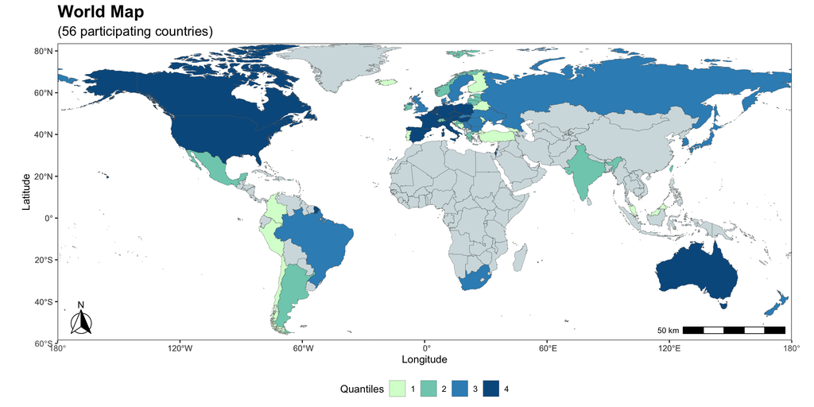

```r
WORLDMAP <-
    WORLDMAP %>%
    filter( admin != "Antarctica") %>%
    mutate (name_sort = toupper( name_sort) )


#append our IBD survey count based on the ISO3 value

WORLD_ISO_CODES <- read_excel("world postal codes.xlsx", sheet = "world postal codes")

WORLD_ISO_CODES <-
    WORLD_ISO_CODES %>%
       mutate( ISO3C = str_pad( ISO3N, 3, pad="0") )



#update SITES with ISO codes, but you have to remove the format from the PERCENT variable first -- SQL doesn't allow "formattable" text

#reconvert PERCENT back to a numeric, unstylized variable

SITES2$PERCENT <- as.numeric(SITES2$PERCENT)



SITES3 <-  sqldf(  "select a.*,
                    case a.COUNTRY when 'USA' then 'USA'
                                   when 'RUSSIA' then 'RUS'
                                   when 'UK' then 'GBR'
                                   when 'KOREA' then 'KOR'
                                   when 'BOSNIA-HERZEGOVINA' then 'BIH' else b.ISO3 end as ISO3,


                    case a.COUNTRY when 'USA' then '840'
                                   when 'RUSSIA' then '643'
                                   when 'UK' then '826'
                                   when 'KOREA' then '410'
                                   when 'BOSNIA-HERZEGOVINA' then '070' else b.ISO3C end as ISO3C
             from SITES2 as a left join
                  WORLD_ISO_CODES as b on (a.COUNTRY = b. CAPNAME)"  )


# replace the desired format

SITES2$PERCENT <- percent(SITES2$PERCENT)



################################################################


#append the COUNT and PERCENTILE from the SITES data frame as variables to the  WORLDMAP sf file

#str(SITES)


WORLDMAP <- left_join( WORLDMAP, SITES3[, -6],
                              by = c("iso_n3" = "ISO3C"))

WORLDMAP <-
    WORLDMAP %>%
    mutate( QRTL = as.factor(QUARTILE) )


cols <- c("1" = "#d7fcd2", "2" = "#7ecdbb", "3" = "#368fc0", "4" = "#045a8d")

ggplot(data = WORLDMAP, aes( fill= QRTL)) +

  geom_sf( lwd=0.1  ) +

  scale_color_manual("Quantiles",
                     values = cols,
                     aesthetics = c("color", "fill"),
                     na.value = "#d2dee0") +

# guides( fill= guide_legend( "Quartile") )
# scale_fill_viridis_c( option = "plasma", trans = "sqrt", begin=1, end=0,  na.value='lightgrey' )+

  theme_bw()+
  xlab("Longitude") + ylab("Latitude") +
  ggtitle("World Map", subtitle = paste0("(", length(unique(SITES$COUNTRY)), " participating countries)")) +
  theme(plot.title =   element_text(color = "black", size = 18, face = "bold", hjust= 0))+
  theme(plot.subtitle= element_text(color = "black", size = 14,  hjust= 0))+
  theme(legend.position= "bottom")  +
 annotation_scale(location = "br", width_hint = 0.15, plot_unit = "km" ) +
  annotation_north_arrow(location = "bl", which_north = "true",
                         pad_x = unit(0.05, "in"), pad_y = unit(0.05, "in"), height= unit(0.5, "in") ,
                         style = north_arrow_fancy_orienteering ) +
  coord_sf( expand= F)
```

#### Task 8: Determine the number of female participants as a percentage of total participants for each CATEGORY of clinical trial (CD, UC, COMBO, etc.).

```r
    IBD2  %>%
      select( CATEGORY, ANALYZED, FEMALES) %>%
        group_by( CATEGORY )  %>%
          summarise( Trials_N = n(), Total_Subjects_N = sum(ANALYZED), Female_N = sum(FEMALES) ,
                     Pct_Female = Female_N / Total_Subjects_N ) %>%
            arrange( as.character(CATEGORY) ) %>%
            rbind(summarise_all(., ~if(is.numeric(.)) sum(.) else "Grand Total"))  %>%
            mutate( Pct_Female = case_when ( CATEGORY == "Grand Total" ~ Female_N / Total_Subjects_N,
                                             TRUE ~ Pct_Female )) %>%

            mutate( Total_Subjects_N = prettyNum(Total_Subjects_N, big.mark=","),
                    Female_N = prettyNum( Female_N, big.mark=","),
                    Pct_Female = percent( Pct_Female ) )   %>%



      kbl( booktabs = T, format= "html",
           caption = "<center><strong>IBD Trials Participation by Gender & Trial Type</strong></center>",
           align= c('l','r','r','r','r'), escape=F,
           col.names = linebreak(c("Category",
                                   "Trials<br>N",
                                   "Total<br>Subjects<br>N",
                                   "Female<br>N",
                                   "Pct<br>Female"))) %>%

           kable_styling(full_width = F, "hover") %>%
                         column_spec(1, width = "8cm") %>%
                          row_spec( 5, bold=T )
```

**IBD Trials Participation by Gender & Trial Type**

Category

Trials  
N

Total  
Subjects  
N

Female  
N

Pct  
Female

1. CD

65

16,365

8,872

54.21%

2. UC

64

20,986

9,309

44.36%

3. IBDU

3

205

103

50.24%

4. COMBO

14

12,632

7,615

60.28%

Grand Total

146

50,188

25,899

51.60%

#### Task 9: Produce a cross tabulation to determine the number and percentage of trials where pregnant women were exlcuded using the **sjPlot** package. (Determine which output is preferable, Table or Stacked Bar.)

```r
require(sjPlot)

#Test first sjPlot cross-tabulation option using all levels of the CATEGORY factor

tab_xtab(var.row = as.character(IBD2$CATEGORY), var.col = IBD2$PREGNANT_EXCL,
         title = "Trials Excluding Pregnant Women", show.row.prc = TRUE)
```

Trials Excluding Pregnant Women

CATEGORY)

PREGNANT_EXCL

Total

N

Y

1. CD

23  
35.4 %

42  
64.6 %

65  
100 %

2. UC

26  
40.6 %

38  
59.4 %

64  
100 %

3. IBDU

2  
66.7 %

1  
33.3 %

3  
100 %

4. COMBO

8  
57.1 %

6  
42.9 %

14  
100 %

Total

59  
40.4 %

87  
59.6 %

146  
100 %

χ<sup>2</sup>=3.170 · df=3 · Cramer’s V=0.147 · Fisher’s p=0.347

```r
#Test second sjPlot option by collapsing two levels of the CATEGORY factor into one: 3.IBDU & 4.COMBO into 3.OTHER

IBD2$CAT2 <-  factor(as.character(IBD2$CATEGORY))
str(IBD2$CAT2)
```

```
##  Factor w/ 4 levels "1. CD","2. UC",..: 1 4 4 1 2 1 2 1 2 1 ...
```

```r
levels(IBD2$CAT2) <- c("1. CD", "2. UC", "3. OTHER", "3. OTHER")
str(IBD2$CAT2)
```

```
##  Factor w/ 3 levels "1. CD","2. UC",..: 1 3 3 1 2 1 2 1 2 1 ...
```

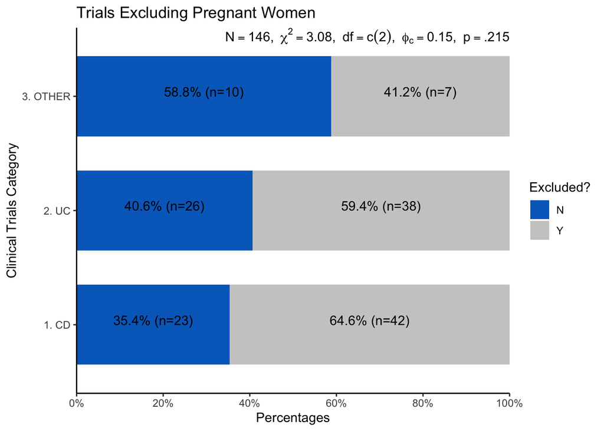

```r
plot_xtab(IBD2$CAT2, IBD2$PREGNANT_EXCL, margin = "row", bar.pos = "stack", coord.flip = TRUE,
          title = "Trials Excluding Pregnant Women",
           axis.titles = c('Clinical Trials Category', 'Percentages'), legend.title= "Excluded?",
          geom.colors = c("#006cc5","#cbcccb"), show.summary = TRUE )+theme_classic()
```

#### Task 10: Determine the racial and ethnic composition of clinical trials where race was reported. (Note that not all trials that reported on race or ethnicty, did so in exactly the same manner. Race may have been limited to as few as three categories or as many as seven, with no real way to identify the methodology used by each study.)

```r
# Use a FOR LOOP to iterate through the `IBD2` data frame that filters it for each discrete category of race or ethnicity (8).
#Pipe those table into an ASSIGN statement that populates each intot he Global Environement.
#Once there, those tables can be concatenated together and piped into the gt package for beautification/formatting.


racecap <-    c('WHT','BLK','ASN','AIA','HPI','MIX','UNK','HIS')

rm(MASTER)


MASTER<- data.frame( RACE_REPORTED= character(0), CATEGORY= character(0), TRIALS_N = numeric(0), TOTAL_SUBJECTS_N = numeric(0),RACE_N = numeric(0),
                     NONRACE_N = numeric(0), PCT_RACE= numeric(0), RACE = character(0) )

for (j in 1: length(racecap) ){
  for (i in 1:3){

    rm(X)

    #create temporary datafram "X and conditionally populate it with three-levels of stats for each racial/ethnic group
    X<-
      if(i==1){

        (    IBD2  %>%
               select( RACE_REPORTED, CATEGORY, ANALYZED, racecap[j] ) %>%
               mutate( NONRACE = ANALYZED - get(racecap[j]) )  %>%
               group_by( RACE_REPORTED, CATEGORY )  %>%
               summarise( TRIALS_N = n(),
                          TOTAL_SUBJECTS_N = sum(ANALYZED, na.rm=T ),
                          RACE_N = sum( get(racecap[j]), na.rm=T ) ,
                          NONRACE_N = sum( NONRACE, na.rm=T  ),
                          PCT_RACE = RACE_N / (RACE_N+NONRACE_N) )  %>%

               arrange( desc(RACE_REPORTED), as.character(CATEGORY)  ) %>%
               filter( RACE_REPORTED == "Y")  %>%

               rbind(summarise_all(., ~if(is.numeric(.)) sum(.) else "Subtotal"))  %>%
               mutate( PCT_RACE = case_when ( CATEGORY == "Subtotal" ~ RACE_N / (RACE_N+NONRACE_N),
                                              TRUE ~ PCT_RACE )) %>%
               mutate( RACE = str_sub(deparse(racecap[j]),2,4)  ) %>% tbl_df   )


      }else if(i==2){

        (    IBD2  %>%
               select( RACE_REPORTED, CATEGORY, ANALYZED, racecap[j] ) %>%
               mutate( NONRACE = ANALYZED - get(racecap[j]) )  %>%
               group_by( RACE_REPORTED, CATEGORY )  %>%
               summarise( TRIALS_N = n(),
                          TOTAL_SUBJECTS_N = sum(ANALYZED, na.rm=T ),
                          RACE_N = sum( get(racecap[j]), na.rm=T ) ,
                          NONRACE_N = sum( NONRACE , na.rm=T ),
                          PCT_RACE = RACE_N / (RACE_N+NONRACE_N) )  %>%

               arrange( desc(RACE_REPORTED), as.character(CATEGORY)  ) %>%
               filter( RACE_REPORTED == "N")  %>%

               rbind(summarise_all(., ~if(is.numeric(.)) sum(.) else "Subtotal"))  %>%
               mutate( PCT_RACE = case_when ( CATEGORY == "Subtotal" ~ RACE_N / (RACE_N+NONRACE_N),
                                              TRUE ~ PCT_RACE )) %>%
               mutate( RACE = str_sub(deparse(racecap[j]),2,4)  ) %>% tbl_df   )



      }else if(i==3){


        ( IBD2  %>%
            select( RACE_REPORTED, CATEGORY, ANALYZED, racecap[j] ) %>%
            mutate( NONRACE = ANALYZED - get(racecap[j]) )  %>%
            mutate( RACE_REPORTED = replace(RACE_REPORTED, RACE_REPORTED !="X", "X"),  CATEGORY= replace(as.character(CATEGORY), as.character(CATEGORY) != "X", "Grand Total")) %>%
            group_by( RACE_REPORTED, CATEGORY )  %>%
            summarise( TRIALS_N = n(),
                       TOTAL_SUBJECTS_N = sum(ANALYZED, na.rm=T ),
                       RACE_N = sum( get(racecap[j]), na.rm=T ) ,
                       NONRACE_N = sum( NONRACE, na.rm=T),
                       PCT_RACE = RACE_N / TOTAL_SUBJECTS_N ) %>%
            mutate( RACE = str_sub(deparse(racecap[j]),2,4)  ) %>%tbl_df )

      }



    #create sequential data frames based on RACE [RACE1-RACE3] to Global Environment populated with the values obtained from the X for loop above
    assign( paste0(racecap[j], i, sep='') , value=  X , envir = .GlobalEnv )

    #confirm the assignment name
 #   print( paste0(racecap[j], i, sep='') )

    X<- as.data.frame(X)


    #rowbind X with a MASTER dataframe that will collect info for all races

    MASTER = rbind( MASTER, X )


  }

  MASTER[ MASTER$RACE_REPORTED=="X", 1] <- ""
  MASTER[ MASTER$RACE_REPORTED=="N", 5:7] <- NA

}
```

Here’s a glimpse of the modified, concatenated data frame, which was named `MASTER` (without any post-processing styling):

```r
head(MASTER)
```

```
##   RACE_REPORTED CATEGORY TRIALS_N TOTAL_SUBJECTS_N RACE_N NONRACE_N  PCT_RACE
## 1             Y    1. CD       22             5973   5385       588 0.9015570
## 2             Y    2. UC       33             9296   7912      1384 0.8511188
## 3             Y  3. IBDU        1               79     77         2 0.9746835
## 4             Y 4. COMBO        7             2879   2547       332 0.8846822
## 5             Y Subtotal       63            18227  15921      2306 0.8734844
## 6             N    1. CD       43            10392     NA        NA        NA
##   RACE
## 1  WHT
## 2  WHT
## 3  WHT
## 4  WHT
## 5  WHT
## 6  WHT
```

```r
tail(MASTER)
```

```
##    RACE_REPORTED    CATEGORY TRIALS_N TOTAL_SUBJECTS_N RACE_N NONRACE_N
## 83             N       1. CD       43            10392     NA        NA
## 84             N       2. UC       31            11690     NA        NA
## 85             N     3. IBDU        2              126     NA        NA
## 86             N    4. COMBO        7             9753     NA        NA
## 87             N    Subtotal       83            31961     NA        NA
## 88               Grand Total      146            50188    647     15265
##      PCT_RACE RACE
## 83         NA  HIS
## 84         NA  HIS
## 85         NA  HIS
## 86         NA  HIS
## 87         NA  HIS
## 88 0.01289153  HIS
```

```r
require(gt)


#Iterative table production using the gt table beautification package

raceshort <-  c("White","Black","Asian","AIA", "HPI", "Mixed","Unknown","Hispanic")
racelong  <-  c("WHITE","BLACK","ASIAN","AMER INDIAN/ALASKAN NATIVE", "HAWAIIAN/PACIFIC ISLANDER","MIXED RACE","UNKNOWN","HISPANIC ETHNICITY")


# j=1
# X<- paste( paste('md("**', raceshort[j], sep=''), 'N**")', sep="<br>")

# install.packages("extrafont")
# extrafont::font_import(pattern = "Calibri")
# extrafont::font_import(pattern = "Josin")



for (j in 1: length(racecap)  ){

  cat("\n\n#####  -", "\n")
  cat("\n\n#### Report ",j," = ", racecap[j], "\n")
  cat("\n\n#####  -", "\n")

RACE<-

  gt(  MASTER[MASTER$RACE== racecap[j] , ],
       groupname_col = "RACE_REPORTED"

  )  %>%
    tab_header(
      title = md("**Race Reported ?**"),
      subtitle = paste("Race =", racelong[j], sep=" ")
    )  %>%

    # tab_footnote(
    #   footnote = paste( paste("Highlights only trials where the race ", racelong[j], sep=" "), "was reported", sep= " "),
    #   locations = cells_title( groups="subtitle")
    # )   %>%

    cols_hide(
      columns = c("RACE")
    ) %>%

    #sets the font for the entire table
    opt_table_font(
      font = c(
        "Helvetica",
        default_fonts()
      )
    ) %>%

    cols_label(
      RACE_REPORTED =     md("**Race<br>Reported**"),
      CATEGORY =          md("**Category**"),
      TRIALS_N =          md("**Trials N**"),
      TOTAL_SUBJECTS_N =  md("**Total Subjects N**"),
      RACE_N =            paste( raceshort[j], "N", sep=' ') ,
      NONRACE_N =         paste(paste("Non-", raceshort[j], sep=""), "N", sep=' ') ,
      PCT_RACE =          paste("Percent", raceshort[j], sep=' ')
    ) %>%

tab_options(
  heading.title.font.weight = "bold",
  heading.title.font.size = "20pt",
  heading.subtitle.font.size = "12pt",
  footnotes.padding = "12pt",
  footnotes.border.bottom.style = NULL,
  heading.padding = "4pt",
  column_labels.font.weight = "bold",
  stub.background.color="#E6EFFC"
) %>%
  #font for Column Labels - redundant
  tab_style(
    style = cell_text(font = "Helvetica"),
    locations= cells_column_labels( columns= everything())
  ) %>%

  #cell formats (does not affect Header & Caption)  >
  tab_style(
    style = cell_text( font =  "Helvetica"),
    locations = cells_body(columns = c(1:7) )
  )  %>%
  #number formats
  fmt_number( columns= c(3:6), decimals=0, sep_mark=",")  %>%
  fmt_percent( columns= 7, decimals=1 )  %>%

  tab_style(
    style = cell_text(align = "right"),
    locations = cells_column_labels(columns = c(3:7))
  ) %>%
  #cell alignment
  tab_style(
    style = cell_text(align = "right"),
    locations = cells_body(columns = c(3:7))
  ) %>%
  #italicizing Subtotal rows
  tab_style(
    style = cell_text(style = "italic"),
    locations = cells_body( rows = c(5, 10) )
  )%>%
  #bold Grand Total
  tab_style(
    style = cell_text(weight = "bold"),
    locations = cells_body( rows = c(11) )
  ) %>%
  tab_style(
    style = cell_text(weight = "bold"),
    locations = cells_body( columns =1 )
  ) %>%
  #adjust columnn widths
  cols_width(
    starts_with("CATEGORY") ~ px(150),
    everything() ~ px(100)
  )  %>%
  #handle missing data NA = em dash
  fmt_missing(
    columns = c(4:7),
    missing_text = "---",
  )

  print(RACE)

  }
```

##### -

#### Report 1 = WHT

##### -

**Race Reported ?**

Race = WHITE

**Category**

**Trials N**

**Total Subjects N**

White N

Non-White N

Percent White

Y

1. CD

22

5,973

5,385

588

90.2%

2. UC

33

9,296

7,912

1,384

85.1%

3. IBDU

1

79

77

2

97.5%

4. COMBO

7

2,879

2,547

332

88.5%

Subtotal

63

18,227

15,921

2,306

87.3%

N

1. CD

43

10,392

—

—

—

2. UC

31

11,690

—

—

—

3. IBDU

2

126

—

—

—

4. COMBO

7

9,753

—

—

—

Subtotal

83

31,961

—

—

—

Grand Total

146

50,188

15,921

2,306

31.7%

##### -

#### Report 2 = BLK

##### -

**Race Reported ?**

Race = BLACK

**Category**

**Trials N**

**Total Subjects N**

Black N

Non-Black N

Percent Black

Y

1. CD

22

5,973

239

5,734

4.0%

2. UC

33

9,296

257

8,424

3.0%

3. IBDU

1

79

1

78

1.3%

4. COMBO

7

2,879

85

2,794

3.0%

Subtotal

63

18,227

582

17,030

3.3%

N

1. CD

43

10,392

—

—

—

2. UC

31

11,690

—

—

—

3. IBDU

2

126

—

—

—

4. COMBO

7

9,753

—

—

—

Subtotal

83

31,961

—

—

—

Grand Total

146

50,188

582

17,030

1.2%

##### -

#### Report 3 = ASN

##### -

**Race Reported ?**

Race = ASIAN

**Category**

**Trials N**

**Total Subjects N**

Asian N

Non-Asian N

Percent Asian

Y

1. CD

22

5,973

305

5,602

5.2%

2. UC

33

9,296

869

8,391

9.4%

3. IBDU

1

79

0

79

0.0%

4. COMBO

7

2,879

198

2,681

6.9%

Subtotal

63

18,227

1,372

16,753

7.6%

N

1. CD

43

10,392

—

—

—

2. UC

31

11,690

—

—

—

3. IBDU

2

126

—

—

—

4. COMBO

7

9,753

—

—

—

Subtotal

83

31,961

—

—

—

Grand Total

146

50,188

1,372

16,753

2.7%

##### -

#### Report 4 = AIA

##### -

**Race Reported ?**

Race = AMER INDIAN/ALASKAN NATIVE

**Category**

**Trials N**

**Total Subjects N**

AIA N

Non-AIA N

Percent AIA

Y

1. CD

22

5,973

12

3,597

0.3%

2. UC

33

9,296

36

5,084

0.7%

3. IBDU

1

79

0

79

0.0%

4. COMBO

7

2,879

3

2,761

0.1%

Subtotal

63

18,227

51

11,521

0.4%

N

1. CD

43

10,392

—

—

—

2. UC

31

11,690

—

—

—

3. IBDU

2

126

—

—

—

4. COMBO

7

9,753

—

—

—

Subtotal

83

31,961

—

—

—

Grand Total

146

50,188

51

11,521

0.1%

##### -

#### Report 5 = HPI

##### -

**Race Reported ?**

Race = HAWAIIAN/PACIFIC ISLANDER

**Category**

**Trials N**

**Total Subjects N**

HPI N

Non-HPI N

Percent HPI

Y

1. CD

22

5,973

5

3,839

0.1%

2. UC

33

9,296

5

4,010

0.1%

3. IBDU

1

79

0

79

0.0%

4. COMBO

7

2,879

3

2,761

0.1%

Subtotal

63

18,227

13

10,689

0.1%

N

1. CD

43

10,392

—

—

—

2. UC

31

11,690

—

—

—

3. IBDU

2

126

—

—

—

4. COMBO

7

9,753

—

—

—

Subtotal

83

31,961

—

—

—

Grand Total

146

50,188

13

10,689

0.0%

##### -

#### Report 6 = MIX

##### -

**Race Reported ?**

Race = MIXED RACE

**Category**

**Trials N**

**Total Subjects N**

Mixed N

Non-Mixed N

Percent Mixed

Y

1. CD

22

5,973

16

3,343

0.5%

2. UC

33

9,296

15

4,596

0.3%

3. IBDU

1

79

1

78

1.3%

4. COMBO

7

2,879

3

518

0.6%

Subtotal

63

18,227

35

8,535

0.4%

N

1. CD

43

10,392

—

—

—

2. UC

31

11,690

—

—

—

3. IBDU

2

126

—

—

—

4. COMBO

7

9,753

—

—

—

Subtotal

83

31,961

—

—

—

Grand Total

146

50,188

35

8,535

0.1%

##### -

#### Report 7 = UNK

##### -

**Race Reported ?**

Race = UNKNOWN

**Category**

**Trials N**

**Total Subjects N**

Unknown N

Non-Unknown N

Percent Unknown

Y

1. CD

22

5,973

61

5,795

1.0%

2. UC

33

9,296

163

8,505

1.9%

3. IBDU

1

79

0

79

0.0%

4. COMBO

7

2,879

40

2,839

1.4%

Subtotal

63

18,227

264

17,218

1.5%

N

1. CD

43

10,392

—

—

—

2. UC

31

11,690

—

—

—

3. IBDU

2

126

—

—

—

4. COMBO

7

9,753

—

—

—

Subtotal

83

31,961

—

—

—

Grand Total

146

50,188

264

17,218

0.5%

##### -

#### Report 8 = HIS

##### -

**Race Reported ?**

Race = HISPANIC ETHNICITY

**Category**

**Trials N**

**Total Subjects N**

Hispanic N

Non-Hispanic N

Percent Hispanic

Y

1. CD

22

5,973

126

4,207

2.9%

2. UC

33

9,296

441

8,447

5.0%

3. IBDU

1

79

0

0

—

4. COMBO

7

2,879

80

2,611

3.0%

Subtotal

63

18,227

647

15,265

4.1%

N

1. CD

43

10,392

—

—

—

2. UC

31

11,690

—

—

—

3. IBDU

2

126

—

—

—

4. COMBO

7

9,753

—

—

—

Subtotal

83

31,961

—

—

—

Grand Total

146

50,188

647

15,265

1.3%

#### Task 11: Determine the Simltaneous Confidence Intervals for Multinomial Proportions (SCIMP) [as proposed by Sison & Glaz](https://www.tandfonline.com/doi/abs/10.1080/01621459.1995.10476521) for the R programming language.

```r
require("MultinomialCI")


# Calculate SCIMP on PARTICIPANTS (no correction indicated, e.g., Bonferroni, Scheffe, Tukey)

A <- sqldf( "select RACE,
                       sum(RACE_N) as  PARTICIPANTS,
                       sum(RACE_N) /sum(sum(RACE_N)) OVER() as PROPORTION


               from MASTER
                where RACE not in ('HIS','UNK') and RACE_REPORTED = 'Y' and CATEGORY != 'Subtotal'
                group by 1 " )


#A<- aggregate( RACE_N ~ RACE, data= MASTER, FUN= sum)
A1<- as.vector(A[ ,2])  #distribution
A2<- as.vector(A[ ,1])  #race names



#Simultaneous CI for multinomial proportions

B<- as.data.frame(multinomialCI( A1, alpha=0.05, verbose=T))
```

```
## [1] "-------------------------------------------------------------"
## [1] "     95 % SIMULTANEOUS CONFIDENCE INTERVALS"
## [1] "       BASED ON THE METHODS OF SISON AND GLAZ"
## [1] "-------------------------------------------------------------"
## [1] "C =  79"
## [1] "P(c+1) =  0.950577037871466"
## [1] "P(c)   =  0.945803360332693"
## [1] "delta =   0.879120894367227"
## [1] "Volume(SG) =  1.72926105201026e-13"
## [1] "Volume(C+1)=  1.7019375035043e-13"
## [1] "PROPORTION" "LOWER(SG)"  "UPPER(SG)"  "LOWER(C+1)" "UPPER(C+1)"
##              [,1]       [,2]        [,3]       [,4]        [,5]
## [1,] 0.0028374318 0.00000000 0.007330491 0.00000000 0.007288305
## [2,] 0.0763324802 0.07193724 0.080825539 0.07188161 0.080783354
## [3,] 0.0323801046 0.02798487 0.036873164 0.02792923 0.036830978
## [4,] 0.0007232669 0.00000000 0.005216326 0.00000000 0.005174140
## [5,] 0.0019472571 0.00000000 0.006440316 0.00000000 0.006398131
## [6,] 0.8857794592 0.88138422 0.890272518 0.88132859 0.890230333
## [1] "SG-midpoint"
## [1] 0.0028863425 0.0763813909 0.0324290153 0.0007721776 0.0019961678
## [6] 0.8858283699
```

```r
#append SCIMP data onto original summary table A

SCIMP <-

  sqldf( "select  A.*,
                    B.v1 as LCL,
                    B.v2 as UCL

            from A, B
            where A.RACE = B.RACE " )



#append Census Distribution from 2019

census <- c( 0.013, 0.059, .134, 0.002, 0.028, 0.763)

SCIMP$CENSUS <- census
SCIMP$CONDLABEL <- ifelse( SCIMP$PROPORTION <= SCIMP$CENSUS, T,F)
SCIMP$CONDVJUST <- ifelse( SCIMP$RACE== "WHT", -0.5, #CHANGE TO 1.0
                   ifelse(SCIMP$RACE== "BLK", -1,
                   ifelse(SCIMP$RACE== "ASN", 1.75,
                   ifelse( SCIMP$RACE== "MIX", -1.5,
                   ifelse( SCIMP$RACE %in% c("AIA","HPI"), -2, -5)))))

SCIMP$CONDHJUST <- ifelse( SCIMP$RACE== "MIX", 1.2, NA)
SCIMP$RACELABEL <- c("Amer Indian\nAlaskan Native", "Asian", "Black", "Hawaiian\nPacific Islander", "Mixed\nRace", "White")




  SCIMP %>%
  select( RACELABEL, PARTICIPANTS, PROPORTION, LCL, UCL) %>%
  mutate( RACELABEL = str_replace(RACELABEL, "\\n", ' '),
          PARTICIPANTS = prettyNum(PARTICIPANTS, big.mark=","),
          PROPORTION =  percent( PROPORTION, digits=2),
          LCL = percent(LCL, digits=2),
          UCL = percent(UCL, digits=2) )  %>%

      kbl( booktabs = T, format= "html",
           align= c('l','r','r','r', 'r'), escape=F,
           caption = "<center><strong>IBD Trials Participatin Distribution by Race with Confidence Intervals</strong></center>",
           col.names = linebreak(c("Race", "Participants<br>N", "Proportion<br>%", "Lower<br>CI", "Upper<br>CI"))) %>%

           kable_styling(full_width = F, "hover") %>% column_spec(1, width = "2")  %>% column_spec(2:5, width="1.5cm")
```

**IBD Trials Participatin Distribution by Race with Confidence Intervals**

| Race | Participants N | Proportion % | Lower CI | Upper CI |
| --- | --- | --- | --- | --- |
| Amer Indian Alaskan Native | 51 | 0.28% | 0.00% | 0.73% |
| Asian | 1,372 | 7.63% | 7.19% | 8.08% |
| Black | 582 | 3.24% | 2.80% | 3.69% |
| Hawaiian Pacific Islander | 13 | 0.07% | 0.00% | 0.52% |
| Mixed Race | 35 | 0.19% | 0.00% | 0.64% |
| White | 15,921 | 88.58% | 88.14% | 89.03% |

#### Task 12: Produce a bar chart plotting the Proportion of enrollment in IBD clinical trials by race, and then overlay a line chart representing the 2019 census proportion for each race.

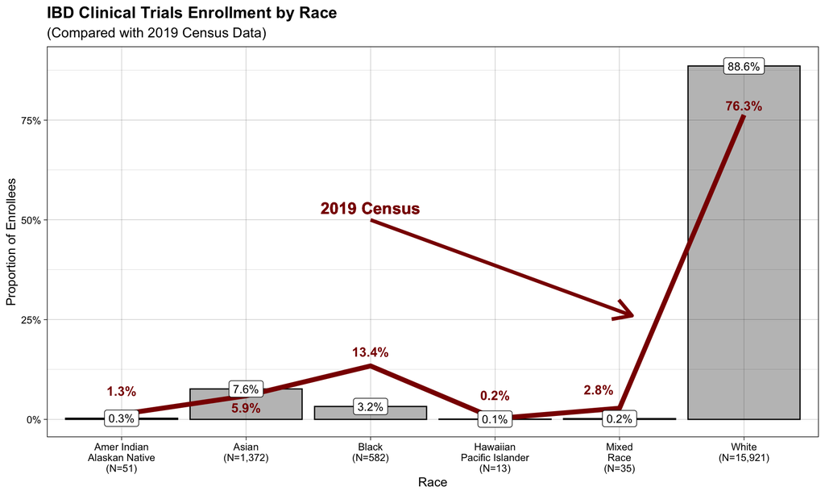

```r
#plot participation and BAR CHART and overlay Census Data as a LINE CHART

ggplot( data= SCIMP, aes(x=RACE, y=PROPORTION, color=RACE, group= 1)) +
  geom_bar( stat='identity', alpha=0.3, position = "dodge", aes(fill= RACE ), fill='black', color='black', ymin=0, ymax=1) +
  geom_line(  aes(x= RACE, y=CENSUS ), color= 'darkred', lwd=2)+
  geom_errorbar(   aes(x= RACE, y=PROPORTION, ymin= LCL , ymax= UCL ,width=0.1), color='blue') +
  geom_label( aes( y=PROPORTION, label= paste0(round(PROPORTION*100,1),'%') ), color='black', size= 3.5 ) +
  scale_y_continuous( labels = scales::percent ) +

  geom_text(  aes( y=CENSUS, label= paste0(round(CENSUS*100,1),'%'), color= CONDLABEL, vjust= CONDVJUST, hjust= CONDHJUST), size=4, fontface="bold") +

  #set up so that races where the IBD-Census ratio is negative could be darkred and those that are positive are darkgreen - set now so that both plot identically
  scale_color_manual( values= c("TRUE" = "darkred", "FALSE" = "darkred"), guide="none") +
  ggtitle("IBD Clinical Trials Enrollment by Race", subtitle = "(Compared with 2019 Census Data)")+
  scale_x_discrete( labels= my_labels) +
  labs( x="Race",y="Proportion of Enrollees", size=10, fontface="bold") +
  theme_linedraw()+
  theme(plot.title =   element_text(color = "black", size = 14, face = "bold", hjust= 0))+
  theme(plot.subtitle= element_text(color = "black", size = 12,  hjust= 0))+

  annotate("segment", x = 'BLK', xend = 5.1, y = .50, yend = .26, colour = "darkred", size=1.5, alpha=1, hjust=2, arrow=arrow() ) +
  geom_text( aes( x= "BLK", y= 0.53, label= "2019 Census"), color="darkred",  size=5 , angle=0, fontface="bold" )
```

```r
 tibble(Race = c('White','Asian','All Others'),
                 IBD  = c(percent(.886, digits=1), percent(0.076, digits=1), percent(0.038, digits=1)),
                 Census  = c(percent(0.763, digits=1), percent(0.059, digits=1), percent(0.177, digits=1)),
                 Delta = c("+12.3", "+1.7", "-13.9") ) %>%

   kbl(booktabs = T, format= "html", align= c('l','r','r','r'), escape=F,
       caption = "<center><strong>IBD Trials Participation vs. 2019 US Census Distribution</strong></center>",
       col.names = linebreak(c("Race", "IBD<br>Trials<br>Pct", "Census<br>2019<br>Pct", "Delta"))) %>%

       kable_styling(full_width = F, "hover") %>%
                     column_spec(1, width = "2in")  %>%
                     column_spec(2:4, width="1in") %>%
                     row_spec(3, bold=T)
```

**IBD Trials Participation vs. 2019 US Census Distribution**

| Race | IBD Trials Pct | Census 2019 Pct | Delta |
| --- | --- | --- | --- |
| White | 88.6% | 76.3% | +12.3 |
| Asian | 7.6% | 5.9% | +1.7 |
| All Others | 3.8% | 17.7% | -13.9 |

#### Task 13: Produce another bar chart plotting the Proportion of enrollment in IBD clinical trials by gender, and then overlay a line chart representing the 2019 census proportion for each gender. (This is essentially a reprise of the previous task.)

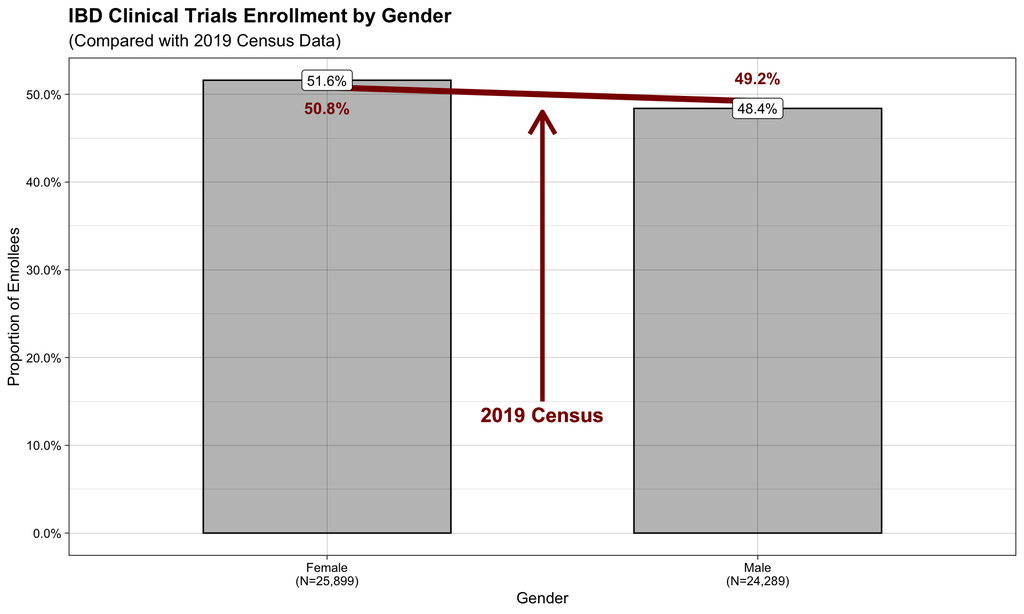

```r
#This code pipes from the original data frame IBD2 to the ggplot graphics package without creating any interim data frames - most R programmmers prefer this

#Female-Male census data from 2019
census2 <- c( 0.508, 0.492)


IBD2 %>%
    select(FEMALES, ANALYZED) %>%
    mutate( MALES = (ANALYZED - FEMALES))  %>%
    select( -ANALYZED) %>%
    pivot_longer( cols= c("FEMALES","MALES"),
                  names_to = "GENDER",
                  values_to = "COUNT" ) %>%
    group_by (GENDER) %>%
    summarise ( COUNT = sum(COUNT) ) %>%
    mutate( PCT = COUNT / sum(COUNT),
            CENSUS = ifelse( GENDER== "FEMALES", census2[1], census2[2]),
            CONDVJUST = ifelse( GENDER== "FEMALES", 2.3, -1.5) ,
            SEX= ifelse( GENDER=="FEMALES", "Female", "Male"),
            GENDLABEL = paste( SEX, "\n(N=", prettyNum( COUNT, big.mark=","), ")", sep = "" ) )  %>%


  ggplot( aes(x= GENDLABEL, y= PCT, color= GENDLABEL, group= 1)) +
  geom_bar( stat='identity', alpha=0.3, position = "dodge", aes(fill= GENDLABEL ), fill='black', color='black',  width=0.575) +
  geom_line(  aes(x= GENDLABEL, y=CENSUS ), color= 'darkred', lwd=2) +
  geom_text(  aes( y= CENSUS, label= paste0(round(CENSUS*100,1),'%'), vjust= CONDVJUST ),  color= 'darkred', size=4, fontface="bold") +
  geom_label( aes( y= PCT, label= paste0(round( PCT*100,1),'%') ), color='black', size= 3.5 ) +
  scale_y_continuous( labels = scales::percent )+
  labs( x="Gender",y="Proportion of Enrollees", size=10, fontface="bold") +
  theme_linedraw()+
  ggtitle("IBD Clinical Trials Enrollment by Gender", subtitle = "(Compared with 2019 Census Data)")+
  theme(plot.title =   element_text(color = "black", size = 14, face = "bold", hjust= 0))+
  theme(plot.subtitle= element_text(color = "black", size = 12,  hjust= 0)) +

  annotate("segment", x = 1.5, xend = 1.5, y = .15, yend = .48, colour = "darkred", size=1.5, alpha=1, arrow=arrow() ) +
  geom_text( aes( x=1.5, y= 0.135, label= "2019 Census"), color="darkred",  size=5 , angle=0, fontface="bold" )
```

Here’s a second version of the Gender bar plot that uses the side-by-side aesthetic:

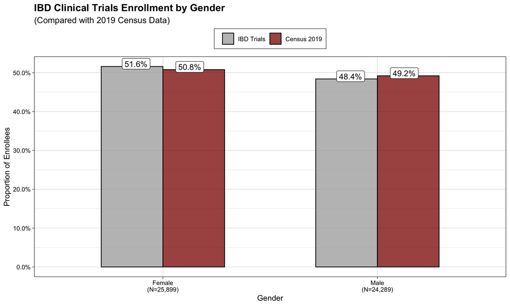

```r
   IBD2 %>%
    select(FEMALES, ANALYZED) %>%
    mutate( MALES = (ANALYZED - FEMALES))  %>%
    select( -ANALYZED) %>%
    pivot_longer( cols= c("FEMALES","MALES"),
                  names_to = "GENDER",
                  values_to = "COUNT" ) %>%
    group_by (GENDER) %>%
    summarise ( COUNT = sum(COUNT) ) %>%
    mutate( PCT = COUNT / sum(COUNT),
            CENSUS = ifelse( GENDER== "FEMALES", census2[1], census2[2]),
            CONDVJUST = ifelse( GENDER== "FEMALES", 2.3, -1.5) ,
            SEX= ifelse( GENDER=="FEMALES", "Female", "Male"),
            GENDLABEL = paste( SEX, "\n(N=", prettyNum( COUNT, big.mark=","), ")", sep = "" ) )  %>%

    pivot_longer( cols= c('PCT', 'CENSUS'),
                  names_to = 'METRIC',
                  values_to= 'PCT') %>%
    select ( -COUNT, -CONDVJUST)  %>%
    mutate( CONDFILL = ifelse( METRIC== "PCT", T, F),
            GENDER = factor(GENDER),
            GENDLABEL = factor(GENDLABEL),
            METRIC =  factor(METRIC, levels= c('PCT','CENSUS') ) ) %>%


    ggplot( aes(x= GENDLABEL, y= PCT, color= METRIC )) +
    geom_bar( stat='identity',  position = "dodge", aes(fill= METRIC, color=METRIC ), color="black", alpha=0.75, width=0.575) +
    geom_label(aes(x= GENDLABEL, label= paste0(round( PCT*100,1),'%') ), color="black",position=position_dodge2(width=0.5), vjust=0.25, size = 4) +

    #since x axis is a character variable, factorize it first!!!
    scale_fill_manual( values= c("darkgrey", "darkred"), labels= c('IBD Trials', 'Census 2019')) +
    scale_y_continuous( labels = scales::percent )+
    labs( x="Gender",y="Proportion of Enrollees", size=10, fontface="bold") +
    theme_linedraw()+
    ggtitle("IBD Clinical Trials Enrollment by Gender", subtitle = "(Compared with 2019 Census Data)")+
    theme(plot.title =   element_text(color = "black", size = 14, face = "bold", hjust= 0))+
    theme(plot.subtitle= element_text(color = "black", size = 12,  hjust= 0)) +
    theme(legend.position = "top", legend.title = element_blank() )+
    theme(legend.background = element_rect(size=0.25, linetype="solid", color ="black"))
```